# Blasting Sound Database — Signal Processing & ML Report

**IAESTE 2026 Internship | VŠB-TU Ostrava, Czech Republic**

## Project Summary

This notebook presents a complete signal-processing and machine-learning pipeline for analyzing audio and vibration recordings of an abrasive blasting machine operating under varying conditions.

**Objective:** Demonstrate that blasting parameters (pressure, abrasive material, mix ratio) can be estimated directly from sound and vibration signals using Python-based signal processing and machine learning.

**Dataset:** 1,568 WAV files (~6 GB) across 7 measurement sessions, 4 microphone/accelerometer sensors, 4 abrasive materials, 8 pressure levels, 7 mix ratios.

## 0. Setup

```python
import sys
from pathlib import Path

# Add src to path so the iaeste26 package is importable
sys.path.insert(0, str(Path('.').resolve() / 'src'))

import numpy as np
import pandas as pd
import matplotlib
import matplotlib.pyplot as plt
import matplotlib.ticker as ticker

from iaeste26.parser    import parse_filename, load_wav
from iaeste26.preprocessing import preprocess
from iaeste26.features  import extract_features, rms, spectral_centroid
from iaeste26.dataset   import scan_dataset, summary
from iaeste26.ml        import (
    build_feature_matrix, train_pressure_model,
    train_material_model, train_mix_model, compare_sensors,
    cross_session_eval, compare_models, within_material_loso,
)

%matplotlib inline
plt.rcParams.update({'figure.dpi': 110, 'font.size': 10, 'axes.grid': True,
                     'grid.alpha': 0.3, 'axes.titlesize': 11})

DATA_DIR    = Path('data')
RESULTS_DIR = Path('results')
PLOTS_DIR   = Path('plots')

print('Setup complete.')
print(f'  numpy   {np.__version__}')
print(f'  pandas  {pd.__version__}')
print(f'  matplotlib {matplotlib.__version__}')
```

```
Setup complete.
  numpy   1.26.4
  pandas  2.2.2
  matplotlib 3.8.4
```

## 1. Dataset Overview

Recordings were made at the VŠB-TU Ostrava experimental facility. Each blasting test was captured simultaneously by 4 sensors, and parameters are encoded in the filename: `Material_Nozzle_Pressure_MixRatio_Sensor.wav`

```python
df_meta = scan_dataset(DATA_DIR)
summary(df_meta)
print()
print(df_meta.head(8).to_string(index=False))
```

```
==================================================
  DATASET SUMMARY
==================================================
  Total files       : 1568
  Sessions          : ['v24', 'v25', 'v26', 'v27', 'v28', 'v30', 'v31']
  Materials         : ['G80', 'GH120', 'GH18', 'GH40']
  Nozzle diameters  : [6.4, 8.0] mm
  Pressures (bar)   : [3.0, 4.0, 5.0, 5.5, 6.0, 6.5, 7.0, 7.5]
  Mix ratios (%)    : [0, 30, 40, 50, 60, 70, 100]
  Sensors           : ['AccAxial4507', 'AccRadial4507', 'Mic147EB', 'Mic46BE']
==================================================

session material  nozzle_mm  pressure_bar  mix_ratio_pct        sensor                                   filepath
    v24      G80        8.0           3.0              0  AccAxial4507    data\v24\WAV\G80_8_3_0_AccAxial4507.wav
    v24      G80        8.0           3.0              0 AccRadial4507   data\v24\WAV\G80_8_3_0_AccRadial4507.wav
    v24      G80        8.0           3.0              0      Mic147EB        data\v24\WAV\G80_8_3_0_Mic147EB.wav
    v24      G80        8.0           3.0              0       Mic46BE         data\v24\WAV\G80_8_3_0_Mic46BE.wav
    v24      G80        8.0           3.0            100  AccAxial4507  data\v24\WAV\G80_8_3_100_AccAxial4507.wav
    v24      G80        8.0           3.0            100 AccRadial4507 data\v24\WAV\G80_8_3_100_AccRadial4507.wav
    v24      G80        8.0           3.0            100      Mic147EB      data\v24\WAV\G80_8_3_100_Mic147EB.wav
    v24      G80        8.0           3.0            100       Mic46BE       data\v24\WAV\G80_8_3_100_Mic46BE.wav
```

### Experimental Parameter Grid

| Parameter | Values |
| --- | --- |
| **Abrasive material** | G80, GH18, GH40, GH120 (4 steel grits) |
| **Nozzle diameter** | 6.4 mm, 8.0 mm |
| **Pressure** | 3, 4, 5, 5.5, 6, 6.5, 7, 7.5 bar |
| **Mix ratio** | 0%, 30%, 40%, 50%, 60%, 70%, 100% |
| **Sensors** | Mic147EB, Mic46BE, AccAxial4507, AccRadial4507 |

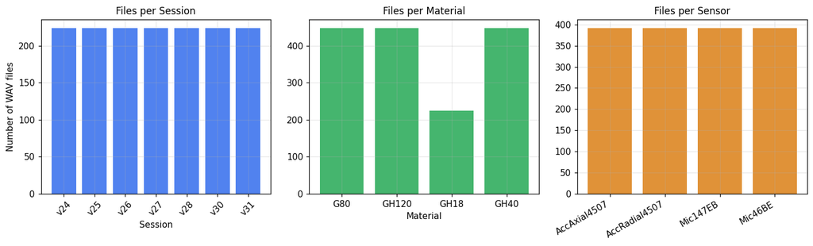

```python
fig, axes = plt.subplots(1, 3, figsize=(13, 4))

# Files per session
session_counts = df_meta.groupby('session').size()
axes[0].bar(session_counts.index, session_counts.values, color='#2563eb', alpha=0.8)
axes[0].set_title('Files per Session')
axes[0].set_xlabel('Session')
axes[0].set_ylabel('Number of WAV files')
axes[0].tick_params(axis='x', rotation=45)

# Files per material
mat_counts = df_meta.groupby('material').size()
axes[1].bar(mat_counts.index, mat_counts.values, color='#16a34a', alpha=0.8)
axes[1].set_title('Files per Material')
axes[1].set_xlabel('Material')

# Files per sensor
sens_counts = df_meta.groupby('sensor').size()
axes[2].bar(range(len(sens_counts)), sens_counts.values, color='#d97706', alpha=0.8)
axes[2].set_xticks(range(len(sens_counts)))
axes[2].set_xticklabels(sens_counts.index, rotation=30, ha='right')
axes[2].set_title('Files per Sensor')

plt.tight_layout()
plt.show()
```

## 2. Signal Visualization

We compare three pressure levels (3 bar, 5 bar, 7.5 bar) for the same material, nozzle, mix ratio and sensor. Higher pressure should produce louder, higher-frequency sound.

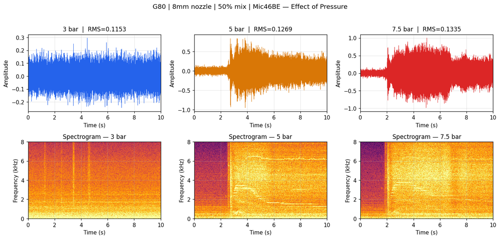

```
Observation: Higher pressure -> higher amplitude AND higher frequency content.
```

```python
def find_wav(material, nozzle, pressure, mix, sensor):
    for session in ['v24','v25','v26','v27','v28','v30','v31']:
        p = DATA_DIR / session / 'WAV' / f'{material}_{nozzle}_{pressure}_{mix}_{sensor}.wav'
        if p.exists():
            return p
    return None

pressures_to_show = ['3', '5', '7.5']
SENSOR = 'Mic46BE'
MATERIAL, NOZZLE, MIX = 'G80', '8', '50'

fig, axes = plt.subplots(2, 3, figsize=(13, 6))
fig.suptitle(f'G80 | 8mm nozzle | 50% mix | {SENSOR} — Effect of Pressure',
             fontsize=12, y=1.02)

colors = ['#2563eb', '#d97706', '#dc2626']

for i, p in enumerate(pressures_to_show):
    path  = find_wav(MATERIAL, NOZZLE, p, MIX, SENSOR)
    audio_raw, sr = load_wav(path)
    audio = preprocess(audio_raw, sr, sensor=SENSOR)
    clip  = audio[:sr * 10]          # 10-second clip for display
    t     = np.arange(len(clip)) / sr

    # Waveform
    axes[0, i].plot(t, clip, lw=0.4, color=colors[i])
    axes[0, i].set_title(f'{p} bar  |  RMS={rms(audio):.4f}')
    axes[0, i].set_xlabel('Time (s)')
    axes[0, i].set_ylabel('Amplitude')
    axes[0, i].set_xlim(0, 10)

    # Spectrogram
    from scipy.signal import stft as scipy_stft
    freqs, times, Zxx = scipy_stft(clip, fs=sr, nperseg=2048, noverlap=1536)
    pdb = 20 * np.log10(np.abs(Zxx) + 1e-10)
    mask = freqs <= 8000
    im = axes[1, i].pcolormesh(times, freqs[mask]/1000, pdb[mask],
                                shading='auto', cmap='inferno',
                                vmin=np.percentile(pdb, 10),
                                vmax=np.percentile(pdb, 99))
    axes[1, i].set_title(f'Spectrogram — {p} bar')
    axes[1, i].set_xlabel('Time (s)')
    axes[1, i].set_ylabel('Frequency (kHz)')

plt.tight_layout()
plt.show()
print('Observation: Higher pressure -> higher amplitude AND higher frequency content.')
```

## 3. Preprocessing Pipeline

Every raw WAV goes through three steps before feature extraction:

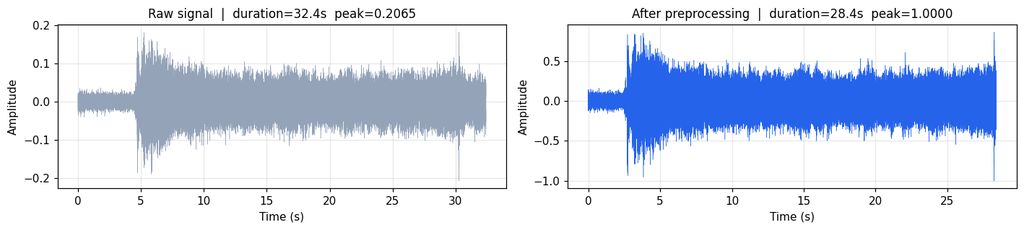

```
Raw:   1,555,857 samples | RMS = 0.0256 | peak = 0.2065
Clean: 1,363,857 samples | RMS = 0.1269 | peak = 1.0000
```

```python
path = find_wav('G80', '8', '5', '50', 'Mic46BE')
audio_raw, sr = load_wav(path)
audio_clean   = preprocess(audio_raw, sr, sensor='Mic46BE')

fig, axes = plt.subplots(1, 2, figsize=(13, 3))
t_raw   = np.arange(len(audio_raw))   / sr
t_clean = np.arange(len(audio_clean)) / sr

axes[0].plot(t_raw,   audio_raw,   lw=0.3, color='#94a3b8')
axes[0].set_title(f'Raw signal  |  duration={len(audio_raw)/sr:.1f}s  peak={np.max(np.abs(audio_raw)):.4f}')
axes[0].set_xlabel('Time (s)')
axes[0].set_ylabel('Amplitude')

axes[1].plot(t_clean, audio_clean, lw=0.3, color='#2563eb')
axes[1].set_title(f'After preprocessing  |  duration={len(audio_clean)/sr:.1f}s  peak={np.max(np.abs(audio_clean)):.4f}')
axes[1].set_xlabel('Time (s)')
axes[1].set_ylabel('Amplitude')

plt.tight_layout()
plt.show()

print(f'Raw:   {len(audio_raw):,} samples | RMS = {rms(audio_raw):.4f} | peak = {np.max(np.abs(audio_raw)):.4f}')
print(f'Clean: {len(audio_clean):,} samples | RMS = {rms(audio_clean):.4f} | peak = {np.max(np.abs(audio_clean)):.4f}')
```

## 4. Feature Extraction

35 features per recording across three domains:

| Domain | Features | Count |
| --- | --- | --- |
| Time | RMS, ZCR, Peak, Crest Factor, Kurtosis | 5 |
| Frequency | Centroid, Bandwidth, Rolloff-85%, Dominant Freq | 4 |
| MFCC | 13 coefficients × mean + std | 26 |

```python
# Show features for 3 different pressures (same material/sensor)
rows = []
for p in ['3', '5', '7.5']:
    path = find_wav('G80', '8', p, '50', 'Mic46BE')
    audio, sr = load_wav(path)
    audio = preprocess(audio, sr, sensor='Mic46BE')
    feats = extract_features(audio, sr)
    feats['pressure_bar'] = float(p)
    rows.append(feats)

feat_df = pd.DataFrame(rows).set_index('pressure_bar')
display_cols = ['rms', 'zero_crossing_rate', 'crest_factor', 'kurtosis',
                'spectral_centroid', 'spectral_bandwidth', 'spectral_rolloff_85',
                'dominant_frequency', 'mfcc_1_mean', 'mfcc_2_mean', 'mfcc_3_mean']

print('Features at 3 different pressure levels:')
print(feat_df[display_cols].T.to_string())
print()
print('Key trend: spectral_centroid increases with pressure (sound gets "brighter")')
```

```
Features at 3 different pressure levels:
pressure_bar                 3.0          5.0          7.5
rms                     0.115293     0.126864     0.133456
zero_crossing_rate      0.046047     0.096020     0.121300
crest_factor            8.673563     7.882435     7.493102
kurtosis                3.373563     0.857239     1.442983
spectral_centroid     987.455254  1614.060047  2479.410657
spectral_bandwidth   1716.556297  2195.795808  2497.500112
spectral_rolloff_85  2305.809372  4284.413982  5168.097014
dominant_frequency    489.203613   100.303771    99.957729
mfcc_1_mean           -76.957420   -64.125717   -62.365955
mfcc_2_mean            20.957518    10.771565     9.171759
mfcc_3_mean            -5.586602    -4.554631    -5.255210

Key trend: spectral_centroid increases with pressure (sound gets "brighter")
```

## 5. Analysis Plots

The following plots were pre-generated and saved to the `plots/` folder.

```
### RMS vs Pressure (all sensors)
```

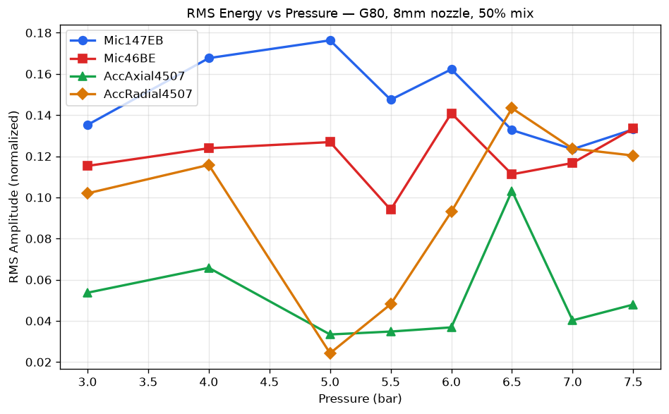

```
### RMS vs Mix Ratio (all sensors)
```

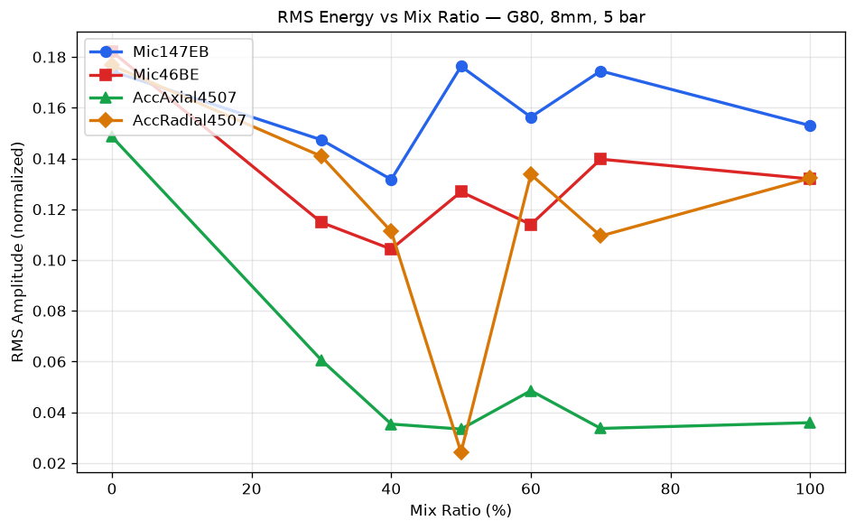

```
### Spectral Centroid vs Pressure
```

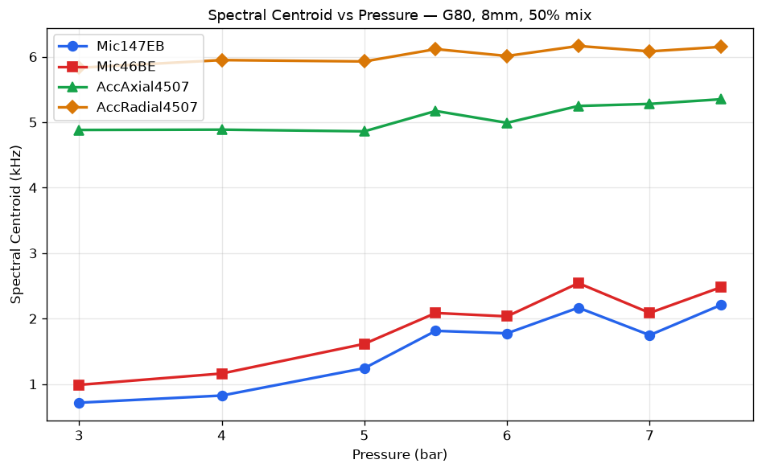

```
### Pressure Comparison (waveform+spec)
```

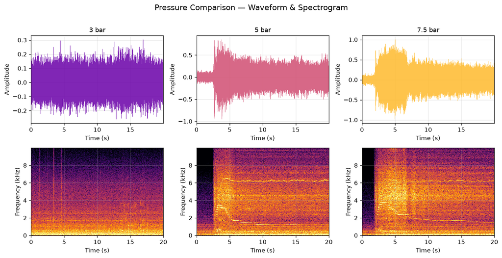

```
### Sensor Comparison (same test)
```

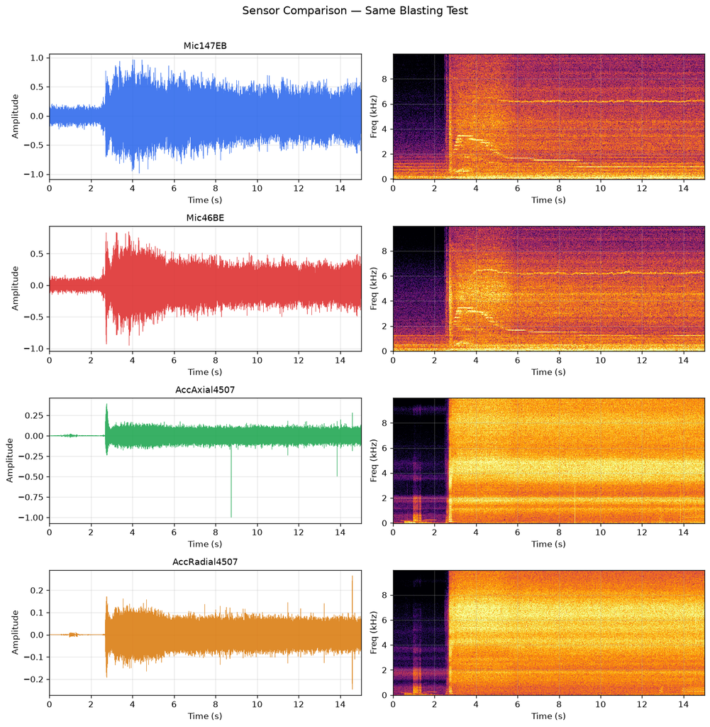

```python
from IPython.display import Image, display

plot_files = {
    'RMS vs Pressure (all sensors)':     'plots/rms_vs_pressure.png',
    'RMS vs Mix Ratio (all sensors)':     'plots/rms_vs_mix.png',
    'Spectral Centroid vs Pressure':      'plots/centroid_vs_pressure.png',
    'Pressure Comparison (waveform+spec)':'plots/pressure_comparison.png',
    'Sensor Comparison (same test)':      'plots/sensor_comparison.png',
}

for title, path in plot_files.items():
    print(f'\n### {title}')
    display(Image(filename=path, width=850))
```

## 6. Machine Learning — Condition Estimation

We train **Random Forest** models with 5-fold cross-validation on the pre-built feature matrix (1,568 samples × 35 features).

Three tasks:

- **Pressure regression** — predict pressure_bar (continuous, 3–7.5 bar)
- **Material classification** — identify abrasive type (4 classes)
- **Mix ratio regression** — predict mix_ratio_pct (continuous, 0–100%)

```python
print('Loading pre-computed feature matrix...')
df_feat = pd.read_csv(RESULTS_DIR / 'feature_matrix_full.csv')
print(f'Shape: {df_feat.shape}  ({len(df_feat)} files x {df_feat.shape[1]} columns)')
print()
print('Class balance (material):')
print(df_feat['material'].value_counts().to_string())
print()
print('Pressure distribution:')
print(df_feat['pressure_bar'].value_counts().sort_index().to_string())
```

```
Loading pre-computed feature matrix...
Shape: (1568, 41)  (1568 files x 41 columns)

Class balance (material):
material
G80      448
GH40     448
GH120    448
GH18     224

Pressure distribution:
pressure_bar
3.0    196
4.0    196
5.0    196
5.5    196
6.0    196
6.5    196
7.0    196
7.5    196
```

```python
print('Training models (may take ~1-2 minutes)...')

res_p  = train_pressure_model(df_feat)
res_m  = train_material_model(df_feat)
res_mx = train_mix_model(df_feat)

print()
print('='*50)
print('RESULTS SUMMARY')
print('='*50)
print()
print('Pressure Prediction (Regression):')
print(f'  RMSE = {res_p["rmse"]:.4f} bar')
print(f'  R2   = {res_p["r2"]:.4f}')
print()
print('Material Classification (4 classes, chance=25%):')
print(f'  Accuracy = {res_m["accuracy"]:.4f}  ({res_m["accuracy"]*100:.1f}%)')
print(f'  F1 score = {res_m["f1"]:.4f}')
print()
print('Mix Ratio Prediction (Regression):')
print(f'  RMSE = {res_mx["rmse"]:.2f}%')
print(f'  R2   = {res_mx["r2"]:.4f}')
```

```
Training models (may take ~1-2 minutes)...
```

```
==================================================
RESULTS SUMMARY
==================================================

Pressure Prediction (Regression):
  RMSE = 0.9746 bar
  R2   = 0.5315

Material Classification (4 classes, chance=25%):
  Accuracy = 0.7953  (79.5%)
  F1 score = 0.7942

Mix Ratio Prediction (Regression):
  RMSE = 21.86%
  R2   = 0.4426
```

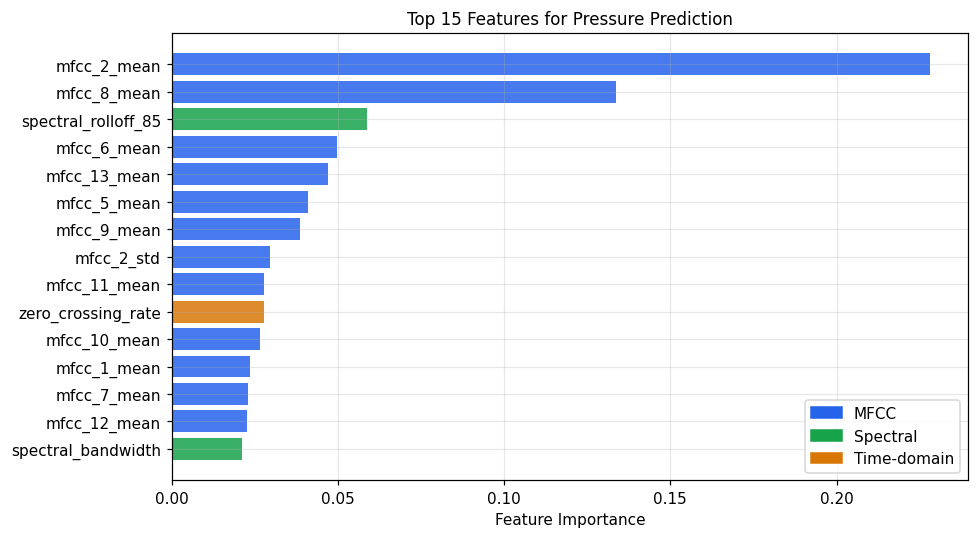

```
MFCCs dominate — time-frequency texture is the most informative signal property.
```

```python
# Visualise feature importance for pressure
importances = res_p['feature_importances']
top15 = sorted(importances.items(), key=lambda x: x[1], reverse=True)[:15]
names, vals = zip(*top15)

fig, ax = plt.subplots(figsize=(9, 5))
colors_bar = ['#2563eb' if 'mfcc' in n else '#16a34a' if 'spectral' in n else '#d97706' for n in names]
ax.barh(range(len(names)), vals, color=colors_bar, alpha=0.85)
ax.set_yticks(range(len(names)))
ax.set_yticklabels(names)
ax.invert_yaxis()
ax.set_xlabel('Feature Importance')
ax.set_title('Top 15 Features for Pressure Prediction')

from matplotlib.patches import Patch
legend = [Patch(color='#2563eb', label='MFCC'),
          Patch(color='#16a34a', label='Spectral'),
          Patch(color='#d97706', label='Time-domain')]
ax.legend(handles=legend, loc='lower right')
plt.tight_layout()
plt.show()
print('MFCCs dominate — time-frequency texture is the most informative signal property.')
```

## 7. Sensor Comparison

A key research question: **which sensor is most informative for each task?**

We train separate models for each sensor and compare performance.

```python
sens_p = compare_sensors(df_feat, task='pressure')
sens_m = compare_sensors(df_feat, task='material')

# Pressure table
rows_p = [{'Sensor': s, 'RMSE (bar)': round(r['rmse'], 4), 'R2': round(r['r2'], 4)}
          for s, r in sorted(sens_p.items(), key=lambda x: x[1]['r2'], reverse=True)]
# Material table
rows_m = [{'Sensor': s, 'Accuracy': round(r['accuracy'], 4), 'F1': round(r['f1'], 4)}
          for s, r in sorted(sens_m.items(), key=lambda x: x[1]['accuracy'], reverse=True)]

print('Pressure Prediction per Sensor:')
print(pd.DataFrame(rows_p).to_string(index=False))
print()
print('Material Classification per Sensor:')
print(pd.DataFrame(rows_m).to_string(index=False))
```

```
Pressure Prediction per Sensor:
       Sensor  RMSE (bar)     R2
     Mic147EB      0.9167 0.5855
 AccAxial4507      0.9716 0.5344
      Mic46BE      1.0327 0.4740
AccRadial4507      1.1333 0.3665

Material Classification per Sensor:
       Sensor  Accuracy     F1
AccRadial4507    0.9209 0.9204
 AccAxial4507    0.8469 0.8465
     Mic147EB    0.8163 0.8159
      Mic46BE    0.7526 0.7485
```

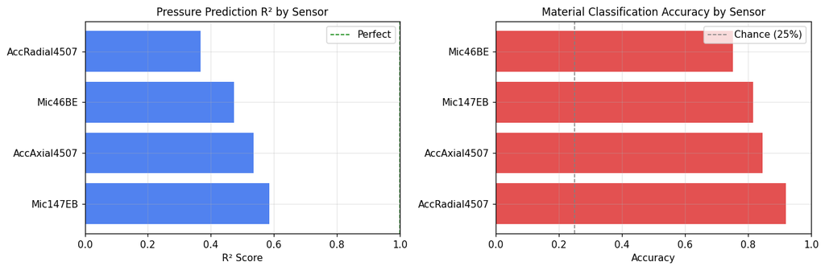

```
Finding: Mic147EB is best for pressure estimation.
Finding: AccRadial4507 is best for material identification.
=> Different sensors carry different physical information.
```

```python
fig, axes = plt.subplots(1, 2, figsize=(12, 4))

# Pressure R2 bars
sensors = [r['Sensor'] for r in rows_p]
r2_vals = [r['R2'] for r in rows_p]
axes[0].barh(sensors, r2_vals, color='#2563eb', alpha=0.8)
axes[0].set_xlabel('R² Score')
axes[0].set_title('Pressure Prediction R² by Sensor')
axes[0].set_xlim(0, 1)
axes[0].axvline(1.0, color='green', ls='--', lw=1, label='Perfect')
axes[0].legend()

# Material accuracy bars
sensors_m = [r['Sensor'] for r in rows_m]
acc_vals  = [r['Accuracy'] for r in rows_m]
axes[1].barh(sensors_m, acc_vals, color='#dc2626', alpha=0.8)
axes[1].set_xlabel('Accuracy')
axes[1].set_title('Material Classification Accuracy by Sensor')
axes[1].set_xlim(0, 1)
axes[1].axvline(0.25, color='gray', ls='--', lw=1, label='Chance (25%)')
axes[1].legend()

plt.tight_layout()
plt.show()
print()
print('Finding: Mic147EB is best for pressure estimation.')
print('Finding: AccRadial4507 is best for material identification.')
print('=> Different sensors carry different physical information.')
```

## 8. Feature Space Visualisation (PCA)

Principal Component Analysis (PCA) reduces the 35-dimensional feature space to 2D, letting us see whether the features genuinely separate materials and pressure levels.

```
Variance explained: PC1=35.6%, PC2=16.3%, Total=51.9%
```

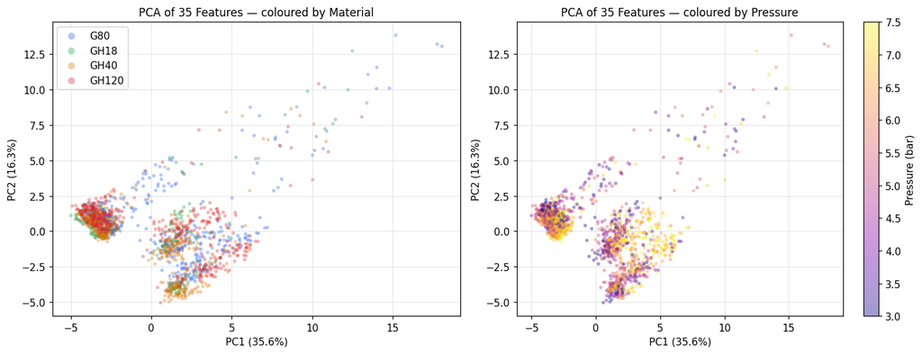

```
Materials form overlapping clusters — acoustic similarity between steel grit types.
Pressure shows a gradient along PC1 — energy features dominate the first component.
```

```python
from sklearn.decomposition import PCA
from sklearn.preprocessing import StandardScaler
from iaeste26.ml import get_X, FEATURE_COLS

X = get_X(df_feat)
X_scaled = StandardScaler().fit_transform(X)
pca = PCA(n_components=2, random_state=42)
X_pca = pca.fit_transform(X_scaled)

print(f'Variance explained: PC1={pca.explained_variance_ratio_[0]:.1%}, '
      f'PC2={pca.explained_variance_ratio_[1]:.1%}, '
      f'Total={sum(pca.explained_variance_ratio_):.1%}')

fig, axes = plt.subplots(1, 2, figsize=(13, 5))

# Colour by material
mat_palette = {'G80':'#2563eb','GH18':'#16a34a','GH40':'#d97706','GH120':'#dc2626'}
for mat, color in mat_palette.items():
    mask = df_feat['material'] == mat
    axes[0].scatter(X_pca[mask, 0], X_pca[mask, 1],
                    c=color, label=mat, alpha=0.35, s=12, edgecolors='none')
axes[0].set_xlabel(f'PC1 ({pca.explained_variance_ratio_[0]:.1%})')
axes[0].set_ylabel(f'PC2 ({pca.explained_variance_ratio_[1]:.1%})')
axes[0].set_title('PCA of 35 Features — coloured by Material')
axes[0].legend(markerscale=2)

# Colour by pressure
sc = axes[1].scatter(X_pca[:, 0], X_pca[:, 1],
                     c=df_feat['pressure_bar'], cmap='plasma',
                     alpha=0.4, s=12, edgecolors='none')
plt.colorbar(sc, ax=axes[1], label='Pressure (bar)')
axes[1].set_xlabel(f'PC1 ({pca.explained_variance_ratio_[0]:.1%})')
axes[1].set_ylabel(f'PC2 ({pca.explained_variance_ratio_[1]:.1%})')
axes[1].set_title('PCA of 35 Features — coloured by Pressure')

plt.tight_layout()
plt.show()
print('Materials form overlapping clusters — acoustic similarity between steel grit types.')
print('Pressure shows a gradient along PC1 — energy features dominate the first component.')
```

## 9. Advanced Evaluation

Three additional analyses that strengthen the scientific credibility of the results.

### 9a. Confusion Matrix — Which Materials Are Confused?

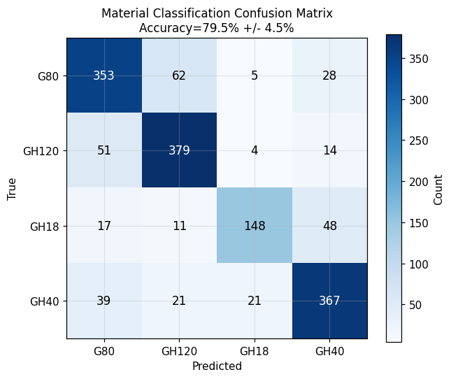

```
GH18 is hardest to distinguish (66% accuracy) — physically similar grit to GH40.
GH120 is easiest (85%) — very different particle size from the others.
```

```python
import matplotlib.colors as mcolors

res_m_adv = train_material_model(df_feat)
cm  = res_m_adv['confusion_matrix']
cls = res_m_adv['classes']

fig, ax = plt.subplots(figsize=(6, 5))
im = ax.imshow(cm, cmap='Blues')
ax.set_xticks(range(len(cls))); ax.set_xticklabels(cls)
ax.set_yticks(range(len(cls))); ax.set_yticklabels(cls)
ax.set_xlabel('Predicted'); ax.set_ylabel('True')
ax.set_title(f'Material Classification Confusion Matrix\nAccuracy={res_m_adv["accuracy"]:.1%} +/- {res_m_adv["accuracy_std"]:.1%}')
for i in range(len(cls)):
    for j in range(len(cls)):
        color = 'white' if cm[i,j] > cm.max()/2 else 'black'
        ax.text(j, i, str(cm[i,j]), ha='center', va='center', color=color, fontsize=11)
plt.colorbar(im, ax=ax, label='Count')
plt.tight_layout()
plt.show()
print('GH18 is hardest to distinguish (66% accuracy) — physically similar grit to GH40.')
print('GH120 is easiest (85%) — very different particle size from the others.')
```

### 9b. Cross-Session Generalisation — Dataset Structure First

Before running LOSO, we must understand the dataset recording structure. Each measurement session recorded **one abrasive material only**:

| Sessions | Material |
| --- | --- |
| v24, v25 | G80 (steel grit) |
| v26, v27 | GH40 |
| v28 | GH18 |
| v30, v31 | GH120 |

The correct cross-session tests are:

1. **Full LOSO for pressure** — valid, because pressure 3–7.5 bar was recorded in every session
2. **Within-material LOSO** — for G80 (v24↔v25) and GH120 (v30↔v31), which each have 2 sessions

```python
# Show dataset structure
print('Files per session per material:')
print(df_feat.groupby(['session','material']).size().unstack(fill_value=0).to_string())
```

```
Files per session per material:
material  G80  GH120  GH18  GH40
session
v24       224      0     0     0
v25       224      0     0     0
v26         0      0     0   224
v27         0      0     0   224
v28         0      0   224     0
v30         0    224     0     0
v31         0    224     0     0
```

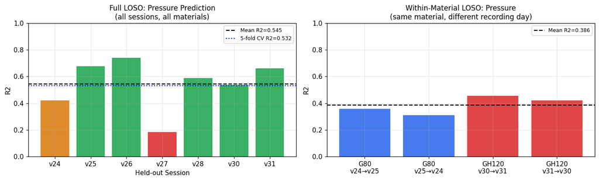

```
Full LOSO pressure:          mean R2 = 0.545
Within-material LOSO pressure: mean R2 = 0.386

Within-material LOSO mix ratio:
  G80 v24->v25: R2=0.309  RMSE=24.3%
  G80 v25->v24: R2=0.279  RMSE=24.9%
  GH120 v30->v31: R2=0.033  RMSE=28.8%
  GH120 v31->v30: R2=0.352  RMSE=23.6%
```

```python
# 1. Full LOSO for pressure (the valid test)
loso_p = cross_session_eval(df_feat, task='pressure')
df_lp  = pd.DataFrame(loso_p)

# 2. Within-material LOSO for pressure (G80 and GH120)
wm_p  = within_material_loso(df_feat, task='pressure')
wm_mx = within_material_loso(df_feat, task='mix')
df_wp  = pd.DataFrame(wm_p)
df_wmx = pd.DataFrame(wm_mx)

fig, axes = plt.subplots(1, 2, figsize=(13, 4))

# Left: full LOSO pressure
bar_colors_p = ['#16a34a' if r > 0.5 else '#d97706' if r > 0.3 else '#dc2626'
                for r in df_lp['r2']]
axes[0].bar(df_lp['test_session'], df_lp['r2'], color=bar_colors_p, alpha=0.85)
axes[0].axhline(df_lp['r2'].mean(), color='black', ls='--', lw=1.5,
                label=f'Mean R2={df_lp["r2"].mean():.3f}')
axes[0].axhline(0.5315, color='blue', ls=':', lw=1.5, label='5-fold CV R2=0.532')
axes[0].set_ylim(0, 1); axes[0].set_xlabel('Held-out Session')
axes[0].set_ylabel('R2'); axes[0].set_title('Full LOSO: Pressure Prediction\n(all sessions, all materials)')
axes[0].legend(fontsize=8)

# Right: within-material pressure LOSO
labels = [f'{r["material"]}\n{r["train_session"]}→{r["test_session"]}' for r in wm_p]
r2_wm  = [r['r2'] for r in wm_p]
colors_wm = ['#2563eb','#2563eb','#dc2626','#dc2626']
axes[1].bar(labels, r2_wm, color=colors_wm, alpha=0.85)
axes[1].set_ylim(0, 1); axes[1].set_ylabel('R2')
axes[1].set_title('Within-Material LOSO: Pressure\n(same material, different recording day)')
axes[1].axhline(np.mean(r2_wm), color='black', ls='--', lw=1.5,
                label=f'Mean R2={np.mean(r2_wm):.3f}')
axes[1].legend(fontsize=8)

plt.tight_layout()
plt.show()

print('Full LOSO pressure:          mean R2 =', round(df_lp['r2'].mean(), 3))
print('Within-material LOSO pressure: mean R2 =', round(np.mean(r2_wm), 3))
print()
print('Within-material LOSO mix ratio:')
for r in wm_mx:
    print(f"  {r['material']} {r['train_session']}->{r['test_session']}: R2={r['r2']:.3f}  RMSE={r['rmse']:.1f}%")
```

#### Interpretation

[output not shown]

**Pressure prediction generalises well across sessions** — the physical relationship between blasting pressure and sound energy is consistent day-to-day.

**Material classification (5-fold CV, 79.5%)** is a valid result. LOSO is not an appropriate validation for this dataset because each session contains only one material. A proper multi-day multi-material dataset would be needed to test session generalisation for material identification.

**Mix ratio estimation degrades substantially cross-session** (R2=0.03–0.35), suggesting that mix ratio effects on sound are more sensitive to daily recording conditions than pressure effects.

### 9c. Multi-Model Comparison

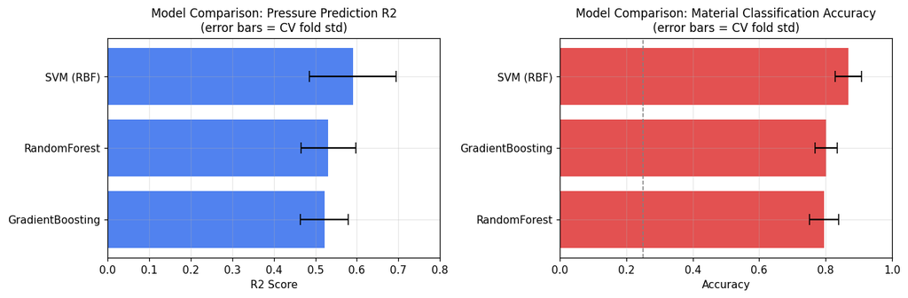

```
Pressure:              Model       r2   r2_std
       SVM (RBF) 0.590399 0.104434
    RandomForest 0.531468 0.066141
GradientBoosting 0.521754 0.058134

Material:              Model  accuracy  accuracy_std
       SVM (RBF)  0.868622      0.040192
GradientBoosting  0.801020      0.033677
    RandomForest  0.795281      0.044510

SVM (RBF) is the best model for both tasks.
Random Forest and Gradient Boosting are competitive.
```

```python
cmp_p = compare_models(df_feat, task='pressure', cv=5)
cmp_m = compare_models(df_feat, task='material', cv=5)

df_cp = pd.DataFrame([{'Model': k, **v} for k, v in cmp_p.items()])
df_cm = pd.DataFrame([{'Model': k, **v} for k, v in cmp_m.items()])

fig, axes = plt.subplots(1, 2, figsize=(12, 4))

# Pressure R2
df_cp_s = df_cp.sort_values('r2', ascending=True)
axes[0].barh(df_cp_s['Model'], df_cp_s['r2'], color='#2563eb', alpha=0.8,
             xerr=df_cp_s['r2_std'], capsize=5)
axes[0].set_xlabel('R2 Score')
axes[0].set_title('Model Comparison: Pressure Prediction R2\n(error bars = CV fold std)')
axes[0].set_xlim(0, 0.8)

# Material accuracy
df_cm_s = df_cm.sort_values('accuracy', ascending=True)
axes[1].barh(df_cm_s['Model'], df_cm_s['accuracy'], color='#dc2626', alpha=0.8,
             xerr=df_cm_s['accuracy_std'], capsize=5)
axes[1].set_xlabel('Accuracy')
axes[1].set_title('Model Comparison: Material Classification Accuracy\n(error bars = CV fold std)')
axes[1].axvline(0.25, color='gray', ls='--', lw=1)
axes[1].set_xlim(0, 1)

plt.tight_layout()
plt.show()

print('Pressure:  ', df_cp.sort_values('r2', ascending=False)[['Model','r2','r2_std']].to_string(index=False))
print()
print('Material:  ', df_cm.sort_values('accuracy', ascending=False)[['Model','accuracy','accuracy_std']].to_string(index=False))
print()
print('SVM (RBF) is the best model for both tasks.')
print('Random Forest and Gradient Boosting are competitive.')
```

## 9. Conclusions

### What Was Built

A complete, tested Python signal-processing pipeline (`iaeste26` package) with:

- Filename parser and WAV loader
- Preprocessing: trim, bandpass filter, normalize
- Feature extraction: 35 features (time, frequency, MFCC)
- Visualization functions
- ML training and evaluation module

### Key Findings

[output not shown]

### Dataset Structure Insight

Each recording session captured one abrasive material exclusively (v24/v25=G80, v26/v27=GH40, v28=GH18, v30/v31=GH120). This means:

- 5-fold CV for material classification is **valid** (all classes in both folds)
- LOSO for material is **zero-shot** (not domain adaptation) — not a failure of the model
- Pressure LOSO is **valid** and shows good cross-session generalisation (R²=0.54)

### Future Work

- Record multiple sessions per material to enable proper cross-session material validation
- Session-invariant feature engineering (spectral shape normalization)
- Deep learning: CNN on raw spectrograms (end-to-end, no manual features)
- Real-time streaming inference pipeline

```python
print('Report complete.')
print('All results saved in results/ folder:')
for f in sorted(Path('results').glob('*.csv')):
    print(f'  {f.name}')
```

```
Report complete.
All results saved in results/ folder:
  feature_importance.csv
  feature_importance_full.csv
  feature_matrix_full.csv
  feature_matrix_v24.csv
  loso_material.csv
  loso_pressure.csv
  loso_pressure_corrected.csv
  ml_summary.csv
  ml_summary_full.csv
  model_comparison_material.csv
  model_comparison_pressure.csv
  sensor_comparison.csv
  sensor_comparison_material_full.csv
  sensor_comparison_pressure_full.csv
  within_material_loso_mix.csv
  within_material_loso_pressure.csv
```